# Yelp Model

### **Set-up**

Load packages

```r
options(scipen=999)
options(dplyr.summarise.inform = FALSE)

library(tidyverse)
library(ggplot2)
library(lubridate)
library(corrplot)
library(readr)
library(caret)
library(randomForest)
"%ni%" <- Negate("%in%")
percentf <- function(x, digits = 2, format = "f", ...) {
  paste0(formatC(100 * x, format = format, digits = digits, ...), "%")
}
```

Load data

### **Data Cleaning**

Preview data

| id | is_claimed | is_closed | review_count | rating | Restaurant Category 1 | Restaurant Category 2 | Restaurant Category 3 | Pickup Available | Delivery Available | Reservation Available | Price Level | number of photos | City | State | Zip Code | Opening Time | Closing Time | Has Messaging |
| --- | --- | --- | --- | --- | --- | --- | --- | --- | --- | --- | --- | --- | --- | --- | --- | --- | --- | --- |
| 9VqZZiaiyGH_6smpvUKaQQ | TRUE | FALSE | 127 | 4.5 | bbq | breakfast_brunch | NA | 0 | 0 | 0 | Medium | 3 | Aubrey | TX | 76227 | 0700 | 2100 | 0 |
| dPaJzxW0foPByEXbPFkh_Q | TRUE | FALSE | 141 | 4.0 | thai | NA | NA | 1 | 1 | 0 | Medium | 3 | Aubrey | TX | 76227 | 1100 | 2130 | 0 |
| RhL6hXqiz_nMz06Xx7tBcg | TRUE | FALSE | 8 | 4.5 | soulfood | foodtrucks | NA | 1 | 1 | 0 | NA | 3 | East Aubrey | TX | 76227 | 1500 | 2100 | 0 |
| yawhLqszfIp9q1aGNdLoig | TRUE | FALSE | 23 | 4.5 | foodtrucks | tacos | NA | 1 | 1 | 0 | Medium | 3 | Aubrey | TX | 76227 | 1100 | 1800 | 0 |
| g_XBHNmwfPUOI4qE_bBgPQ | TRUE | FALSE | 83 | 3.0 | japanese | sushi | NA | 1 | 1 | 0 | NA | 3 | Aubrey | TX | 76227 | 1100 | 1430 | 1 |
| n9xpJEWHDFXu5AdrOWBILQ | TRUE | FALSE | 8 | 3.5 | seafood | NA | NA | 0 | 0 | 0 | NA | 3 | Aubrey | TX | 76227 | 1400 | 2000 | 1 |

Check NAs

```r
df %>%
  select(-id) %>%
  summarise_all(funs(sum(is.na(.))))
```

| is_claimed | is_closed | review_count | rating | Restaurant Category 1 | Restaurant Category 2 | Restaurant Category 3 | Pickup Available | Delivery Available | Reservation Available | Price Level | number of photos | City | State | Zip Code | Opening Time | Closing Time | Has Messaging |
| --- | --- | --- | --- | --- | --- | --- | --- | --- | --- | --- | --- | --- | --- | --- | --- | --- | --- |
| 0 | 0 | 0 | 0 | 0 | 530 | 1224 | 0 | 0 | 0 | 655 | 0 | 0 | 0 | 0 | 217 | 217 | 0 |

> **Observations*: a restaurant can have as many as 3 categories but it must have at min 1 catgory. Price is not required (impute or mark as NA?) Some records are missing opening/closing time

#### Add Breakfast/Lunch/Dinner/Late.

If Opening/Closing Time is NULL, can we determine breakfast/lunch/dinner/late status using restaurant category?

```r
df <-
df %>%
  # convert time string to hour int
  mutate(open_hour=as.integer(substr(`Opening Time`,1,2)),
         close_hour=as.integer(substr(`Closing Time`,1,2))) %>%

  # if open before/at 10:00 -> breakfast
  # if open before/at 12:00 -> lunch
  # if open before/at 18:00 -> dinner
  # if close after 22:00 -> late
  mutate(Open_Breakfast = if_else(open_hour <= 10,1,0),
         Open_Lunch = if_else(open_hour <= 12 & close_hour >= 12,1,0),
         Open_Dinner = if_else(open_hour <= 18 & (close_hour >= 18 | close_hour <=2),1,0),
         Open_Late = if_else(close_hour >= 22 | close_hour <= 2,1,0))
```

#### Chunk restaurant categories

We’ll have to one-hot encode the restaurant categories. Too many categories will result in a large feature set. How many unique restaurant categories are there?

```r
# get the distinct restaurant categories across all 3 columns
rbind(df %>% select(restaurant_category=`Restaurant Category 1`),
      df %>% select(restaurant_category=`Restaurant Category 2`),
      df %>% select(restaurant_category=`Restaurant Category 3`)) %>%
  distinct()
```

| restaurant_category |
| --- |
| bbq |
| thai |
| soulfood |
| foodtrucks |
| japanese |
| seafood |
| salad |
| tradamerican |
| coffee |
| hotdogs |

[output cut: 169 more lines]

Manually chunk these categories into larger categories.

> **Note**: this information loss may affect our model negatively. We may need to re-evaluate which and how many categories we’re using

```r
df <-
df %>%
  mutate(restaurant_category=case_when(`Restaurant Category 1` %in% c("thai","japanese","chinese","asianfusion","sushi","indpak","noodles","vietnamese","pakistani",
                                                                      "laotian","ramen","korean","mongolian","dimsum","taiwanese","hotpot","filipino","conveyorsushi",
                                                                      "teppanyaki","cantonese","izakaya","japacurry","panasian","karaoke") |
                                       `Restaurant Category 2` %in% c("thai","japanese","chinese","asianfusion","sushi","indpak","noodles","vietnamese","pakistani",
                                                                    "laotian","ramen","korean","mongolian","dimsum","taiwanese","hotpot","filipino","conveyorsushi",
                                                                    "teppanyaki","cantonese","izakaya","japacurry","panasian","karaoke") |
                                       `Restaurant Category 3` %in% c("thai","japanese","chinese","asianfusion","sushi","indpak","noodles","vietnamese","pakistani",
                                                                    "laotian","ramen","korean","mongolian","dimsum","taiwanese","hotpot","filipino","conveyorsushi",
                                                                    "teppanyaki","cantonese","izakaya","japacurry","panasian","karaoke") ~"asian",

                                       `Restaurant Category 1` %in% c("italian","greek","portuguese","french","scandinavian","spanish","tapasmallplates","tapas",
                                                                      "british","fishnchips","german","irish","pastashops","modern_european","mediterranean") |
                                       `Restaurant Category 2` %in% c("italian","greek","portuguese","french","scandinavian","spanish","tapasmallplates","tapas",
                                                                      "british","fishnchips","german","irish","pastashops","modern_european","mediterranean") |
                                       `Restaurant Category 3` %in% c("italian","greek","portuguese","french","scandinavian","spanish","tapasmallplates","tapas",
                                                                      "british","fishnchips","german","irish","pastashops","modern_european","mediterranean") ~"european",

                                       `Restaurant Category 1` %in% c("mideastern","halal","persian","turkish","falafel","syrian","kebab","lebanese","armenian")|
                                       `Restaurant Category 2` %in% c("mideastern","halal","persian","turkish","falafel","syrian","kebab","lebanese","armenian")|
                                       `Restaurant Category 3` %in% c("mideastern","halal","persian","turkish","falafel","syrian","kebab","lebanese","armenian")~"mideastern",

                                       `Restaurant Category 1` %in% c("latin","tex-mex","mexican","salvadoran","tacos","brazilian","newmexican")|
                                       `Restaurant Category 2` %in% c("latin","tex-mex","mexican","salvadoran","tacos","brazilian","newmexican")|
                                       `Restaurant Category 3` %in% c("latin","tex-mex","mexican","salvadoran","tacos","brazilian","newmexican")~"latin",

                                       `Restaurant Category 1` %in% c("bbq","soulfood","salad","tradamerican","hotdogs","sandwiches","pizza","burgers","chicken_wings",
                                                                      "chickenshop","soup","delis","newamerican","hotdog","southern","cajun","cheesesteaks","smokehouse",
                                                                      "steak") |
                                       `Restaurant Category 2` %in% c("bbq","soulfood","salad","tradamerican","hotdogs","sandwiches","pizza","burgers","chicken_wings",
                                                                      "chickenshop","soup","delis","newamerican","hotdog","southern","cajun","cheesesteaks","smokehouse",
                                                                      "steak") |
                                       `Restaurant Category 3` %in% c("bbq","soulfood","salad","tradamerican","hotdogs","sandwiches","pizza","burgers","chicken_wings",
                                                                      "chickenshop","soup","delis","newamerican","hotdog","southern","cajun","cheesesteaks","smokehouse",
                                                                      "steak")~"american",

                                       `Restaurant Category 1` %in% c("shavedice","desserts","icecream","cakeshop","bakeries","bubbletea","creperies","donuts","waffles",
                                                                      "cupcakes","gelato")|
                                       `Restaurant Category 2` %in% c("shavedice","desserts","icecream","cakeshop","bakeries","bubbletea","creperies","donuts","waffles",
                                                                      "cupcakes","gelato")|
                                       `Restaurant Category 3` %in% c("shavedice","desserts","icecream","cakeshop","bakeries","bubbletea","creperies","donuts","waffles",
                                                                      "cupcakes","gelato")~"desserts",

                                       `Restaurant Category 1` %in% c("breakfast_brunch","coffee","cafes","acaibowls","juicebars","pancakes","diners") |
                                       `Restaurant Category 2` %in% c("breakfast_brunch","coffee","cafes","acaibowls","juicebars","pancakes","diners") |
                                       `Restaurant Category 3` %in% c("breakfast_brunch","coffee","cafes","acaibowls","juicebars","pancakes","diners") ~"breakfast",

                                       `Restaurant Category 1` %in% c("hawaiian","poke") |
                                       `Restaurant Category 2` %in% c("hawaiian","poke") |
                                       `Restaurant Category 3` %in% c("hawaiian","poke") ~"hawaiian",

                                       TRUE~"other"))
```

How many records are still missing restaurant_category?

```r
df %>%
  summarise(total_records=sum(n()),
            missing_restaurant_cat=sum(restaurant_category=='other')) %>%
  mutate(missing_percent=percentf(missing_restaurant_cat/total_records))
```

| total_records | missing_restaurant_cat | missing_percent |
| --- | --- | --- |
| 2356 | 47 | 1.99% |

#### Misc. Cleaning

I noticed the grid search pulled in records from other states. Filter for the states we need:

```r
df %>% group_by(State) %>% tally()
df <- df %>% filter(State %in% c('ID','TX','NV'))
```

Translate ‘is_claimed’ to boolean

```r
df <- df %>% mutate(is_claimed=if_else(is_claimed=='TRUE',1,0))
```

### **One-Hot Encode**

```r
# select the features we need
df_select <-
df %>%
  select(is_claimed,review_count,rating,restaurant_category,pickup=`Pickup Available`,delivery=`Delivery Available`,reservation=`Reservation Available`, price,State,messaging=`Has Messaging`,Open_Breakfast,Open_Lunch,Open_Dinner,Open_Late)
```

One-hot encode categorical features

```r
dummy <- dummyVars("~.",data=df_select)
df_onehot <- data.frame(predict(dummy,newdata=df_select))
head(df_onehot)
```

|  | is_claimed | review_count | rating | restaurant_categoryamerican | restaurant_categoryasian | restaurant_categorybreakfast | restaurant_categorydesserts | restaurant_categoryeuropean | restaurant_categoryhawaiian | restaurant_categorylatin | restaurant_categorymideastern | restaurant_categoryother | pickup | delivery | reservation | priceHigh | priceLow | priceMedium | priceNA | priceVery.High | StateID | StateNV | StateTX | messaging | Open_Breakfast | Open_Lunch | Open_Dinner | Open_Late |
| --- | --- | --- | --- | --- | --- | --- | --- | --- | --- | --- | --- | --- | --- | --- | --- | --- | --- | --- | --- | --- | --- | --- | --- | --- | --- | --- | --- | --- |
| 1 | 1 | 127 | 4.5 | 1 | 0 | 0 | 0 | 0 | 0 | 0 | 0 | 0 | 0 | 0 | 0 | 0 | 0 | 1 | 0 | 0 | 0 | 0 | 1 | 0 | 1 | 1 | 1 | 0 |
| 2 | 1 | 141 | 4.0 | 0 | 1 | 0 | 0 | 0 | 0 | 0 | 0 | 0 | 1 | 1 | 0 | 0 | 0 | 1 | 0 | 0 | 0 | 0 | 1 | 0 | 0 | 1 | 1 | 0 |
| 3 | 1 | 8 | 4.5 | 1 | 0 | 0 | 0 | 0 | 0 | 0 | 0 | 0 | 1 | 1 | 0 | 0 | 0 | 0 | 1 | 0 | 0 | 0 | 1 | 0 | 0 | 0 | 1 | 0 |
| 4 | 1 | 23 | 4.5 | 0 | 0 | 0 | 0 | 0 | 0 | 1 | 0 | 0 | 1 | 1 | 0 | 0 | 0 | 1 | 0 | 0 | 0 | 0 | 1 | 0 | 0 | 1 | 1 | 0 |
| 5 | 1 | 83 | 3.0 | 0 | 1 | 0 | 0 | 0 | 0 | 0 | 0 | 0 | 1 | 1 | 0 | 0 | 0 | 0 | 1 | 0 | 0 | 0 | 1 | 1 | 0 | 1 | 0 | 0 |
| 6 | 1 | 8 | 3.5 | 0 | 0 | 0 | 0 | 0 | 0 | 0 | 0 | 1 | 0 | 0 | 0 | 0 | 0 | 0 | 1 | 0 | 0 | 0 | 1 | 1 | 0 | 0 | 1 | 0 |

### **Random Forest**

Originally we intended to train a linear/logistic regression. However, the target variable (rating) is technically ordinal (1 star, 1.5 stars, 2 stars, 2.5 stars, etc.) which means our data will not meet the data assumptions. Instead, we will build a random forest using out of bag error estimation.

```
mtry = 5  OOB error = 29.23%
Searching left ...
mtry = 4    OOB error = 29.06%
0.005813953 0.00001
mtry = 3    OOB error = 28.8%
0.00877193 0.00001
mtry = 2    OOB error = 30.54%
-0.06047198 0.00001
Searching right ...
mtry = 7    OOB error = 29.65%
-0.02949853 0.00001
```

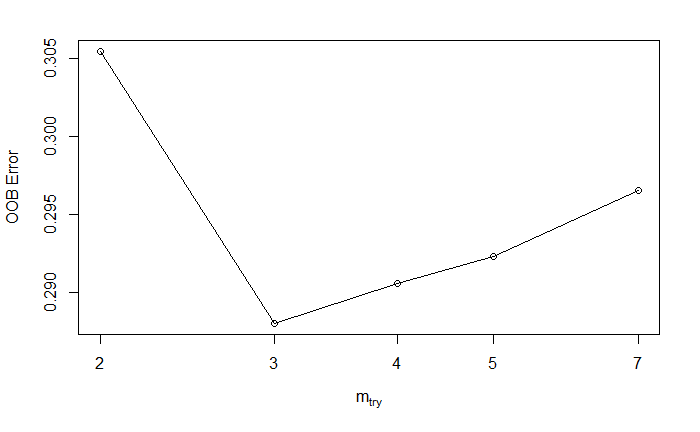

```r
set.seed(149)
bestMtry <- tuneRF(df_model[-3],df_model$rating, ntreeTry=500,
               stepFactor=1.5,improve=1e-5, trace=TRUE, plot=TRUE)
```

```r
# --- bucket the rating (ordinal) to "high"/"low" (categorical)
df_model <-
  df_onehot %>%
  mutate(rating=case_when(rating <= 3.5~'low',
                          TRUE~'high'))

set.seed(149)
# --- split training 80:20
inTraining <- createDataPartition(df_model$rating, p = .8, list = FALSE)
training <- df_model[ inTraining,]
testing  <- df_model[-inTraining,]

set.seed(149)
# --- use out-of-bag method for error estimation.
control <- trainControl(method = "oob", number=5, verboseIter=TRUE, savePredictions=TRUE)

# search: hyperparameter search (grid, random); random search works better for lower dimensional data; for rf, you can tune mtry (number of variables to randomly sample as candidates at each split)
# number: number of resampling iterations (numeric)
# sampling: sampling method (up,down)

repGrid <- expand.grid(.mtry=c(4))

model <- train(rating ~., data=training,
               method="rf",
               trControl = control,
               tuneGrid = repGrid)
```

```
+ : mtry=4
- : mtry=4
```

```r
print(model)
```

```
Random Forest

1884 samples
  27 predictor
   2 classes: 'high', 'low'

No pre-processing
Resampling results:

  Accuracy   Kappa
  0.7059448  0.3965009

Tuning parameter 'mtry' was held constant at a value of 4
```

If instead of using mtry from tuneRF, can I try multiple mtry values using randomsearch?

```r
# --- bucket the rating (ordinal) to "high"/"low" (categorical)
df_model <-
  df_onehot %>%
  mutate(rating=case_when(rating <= 3.5~'low',
                          TRUE~'high'))

set.seed(149)
# --- split training 80:20
inTraining <- createDataPartition(df_model$rating, p = .8, list = FALSE)
training <- df_model[ inTraining,]
testing  <- df_model[-inTraining,]

set.seed(149)

# --- use out-of-bag method for error estimation
# --- search: hyperparameter search (grid, random); random search works better for lower dimensional data; for rf, you can tune mtry (number of variables to randomly sample as candidates at each split)
# --- number: number of resampling iterations (numeric)

control <- trainControl(method = "oob", number=5, search="random", verboseIter=TRUE, savePredictions=TRUE)

model <- train(rating ~., data=training,
               method="rf",
               trControl = control)
```

```
+ : mtry=23
- : mtry=23
+ : mtry= 8
- : mtry= 8
+ : mtry=12
- : mtry=12
```

```r
print(model)
```

```
Random Forest

1884 samples
  27 predictor
   2 classes: 'high', 'low'

No pre-processing
Resampling results across tuning parameters:

  mtry  Accuracy   Kappa
   8    0.7096603  0.4088413
  12    0.6958599  0.3805704
  23    0.6947983  0.3775440

Accuracy was used to select the optimal model using the largest value.
The final value used for the model was mtry = 8.
```

> **Observation**: using caret’s randomsearch, mtry 8 was recommended, though the accuracy is about the same

Can performance be improved if I upsample the positive (“high”) class? Keep randomsearch for mtry value

```r
# --- bucket the rating (ordinal) to "high"/"low" (categorical)
df_model <-
  df_onehot %>%
  mutate(rating=case_when(rating <= 3.5~'low',
                          TRUE~'high'))

set.seed(149)
# --- split training 80:20
inTraining <- createDataPartition(df_model$rating, p = .8, list = FALSE)
training <- df_model[ inTraining,]
testing  <- df_model[-inTraining,]

set.seed(149)

# --- use out-of-bag method for error estimation
# --- search: hyperparameter search (grid, random); random search works better for lower dimensional data; for rf, you can tune mtry (number of variables to randomly sample as candidates at each split)
# --- number: number of resampling iterations (numeric)
# --- sampling: sampling method (up,down)

control <- trainControl(method = "oob", number=5, sampling="up", search="random", verboseIter=TRUE, savePredictions=TRUE)

model <- train(rating ~., data=training,
               method="rf",
               trControl = control)
```

```
+ : mtry=23
- : mtry=23
+ : mtry= 8
- : mtry= 8
+ : mtry=12
- : mtry=12
```

```r
print(model)
```

```
Random Forest

1884 samples
  27 predictor
   2 classes: 'high', 'low'

No pre-processing
Addtional sampling using up-sampling

Resampling results across tuning parameters:

  mtry  Accuracy   Kappa
   8    0.7511759  0.5023518
  12    0.7582314  0.5164628
  23    0.7568203  0.5136406

Accuracy was used to select the optimal model using the largest value.
The final value used for the model was mtry = 12.
```

Variable importance

```r
varImp(model)
```

```
rf variable importance

  only 20 most important variables shown (out of 27)
```

|  | Overall |
| --- | --- |
| review_count | 100.000000 |
| Open_Late | 22.112617 |
| priceLow | 13.061142 |
| messaging | 10.424828 |
| Open_Breakfast | 10.357694 |
| pickup | 9.805930 |
| restaurant_categoryamerican | 8.631676 |
| delivery | 8.504584 |
| Open_Lunch | 8.271801 |
| StateNV | 7.883021 |

[output cut: 10 more lines]

> **Observations**: review_count is highly predictive, which makes sense given review_count is a factor of time, and if a business has been around for along time, it’s likely successful. State is also predictive, but since we want our model to predict across states/cities, can State be removed while maintaining an acceptable accuracy? Also can we remove restaurants that have very low review count? e.g. <=10

**Final Model!!**

```r
# --- bucket the rating (ordinal) to "high"/"low" (categorical)
df_model <-
  df_onehot %>%
  mutate(rating=case_when(rating <= 3.5~'low',
                          TRUE~'high')) %>%
  filter(review_count > 10)

set.seed(149)
# --- split training 80:20
inTraining <- createDataPartition(df_model$rating, p = .8, list = FALSE)
training <- df_model[ inTraining,] %>% select(-StateID, -StateNV, -StateTX)
testing  <- df_model[-inTraining,]

set.seed(149)

# --- use out-of-bag method for error estimation
# --- search: hyperparameter search (grid, random); random search works better for lower dimensional data; for rf, you can tune mtry (number of variables to randomly sample as candidates at each split)
# --- number: number of resampling iterations (numeric)
# --- sampling: sampling method (up,down)

control <- trainControl(method = "oob", number=5, sampling="up", search="random", verboseIter=TRUE, savePredictions=TRUE)

model <- train(rating ~., data=training,
               method="rf",
               trControl = control)
```

```
+ : mtry=23
- : mtry=23
+ : mtry= 8
- : mtry= 8
+ : mtry=12
- : mtry=12
```

```r
print(model)
```

```
Random Forest

1580 samples
  24 predictor
   2 classes: 'high', 'low'

No pre-processing
Addtional sampling using up-sampling

Resampling results across tuning parameters:

  mtry  Accuracy   Kappa
   8    0.7700000  0.5400000
  12    0.7694444  0.5388889
  23    0.7627778  0.5255556

Accuracy was used to select the optimal model using the largest value.
The final value used for the model was mtry = 8.
```

Predict on test set and create confusion matrix

```r
# --- feature importance
varImp(model)
```

```
rf variable importance

  only 20 most important variables shown (out of 24)
```

|  | Overall |
| --- | --- |
| review_count | 100.000000 |
| Open_Late | 32.921257 |
| priceLow | 13.698604 |
| Open_Breakfast | 11.823679 |
| pickup | 10.851975 |
| messaging | 10.629273 |
| restaurant_categoryamerican | 9.695250 |
| Open_Lunch | 9.553803 |
| delivery | 9.078172 |
| Open_Dinner | 8.494066 |

[output cut: 10 more lines]

```r
# --- confusion matrix on test data
predict(model, newdata = testing) %>%
  confusionMatrix(., as.factor(testing$rating))
```

```
Confusion Matrix and Statistics

          Reference
Prediction high low
      high  123  74
      low    47 151

               Accuracy : 0.6937
                 95% CI : (0.6456, 0.7388)
    No Information Rate : 0.5696
    P-Value [Acc > NIR] : 0.0000002693

                  Kappa : 0.3871

 Mcnemar's Test P-Value : 0.0181

            Sensitivity : 0.7235
            Specificity : 0.6711
         Pos Pred Value : 0.6244
         Neg Pred Value : 0.7626
             Prevalence : 0.4304
         Detection Rate : 0.3114
   Detection Prevalence : 0.4987
      Balanced Accuracy : 0.6973

       'Positive' Class : high
```

#### Random Forest by City

For each city, build a random forest. Are there different features that are important based on the city?

Frisco, TX

```r
df_city <-
df %>%
  filter(review_count > 10 & City %in% c('Frisco','FRISCO')) %>%
  mutate(price=if_else(is.na(`Price Level`),"NA",`Price Level`)) %>%
  select(is_claimed,review_count,rating,restaurant_category,pickup=`Pickup Available`,delivery=`Delivery Available`,reservation=`Reservation Available`,
         price,messaging=`Has Messaging`,Open_Breakfast,Open_Lunch,Open_Dinner,Open_Late)

dummy <- dummyVars("~.",data=df_city)
df_onehot <- data.frame(predict(dummy,newdata=df_city))


df_model <-
  df_onehot %>%
  mutate(rating=case_when(rating <= 3.5~'low',
                          TRUE~'high'))


set.seed(149)
# --- split training 80:20
inTraining <- createDataPartition(df_model$rating, p = .8, list = FALSE)
training <- df_model[ inTraining,]
testing  <- df_model[-inTraining,]

set.seed(149)

# --- use out-of-bag method for error estimation.
control <- trainControl(method = "oob", number=5, sampling="up", search="random", verboseIter=TRUE, savePredictions=TRUE)

# search: hyperparameter search (grid, random); random search works better for lower dimensional data; for rf, you can tune mtry (number of variables to randomly sample as candidates at each split) and ntree (number of branches will grow after each time split)
# number: number of resampling iterations (numeric)
# sampling: sampling method (up,down)

model <- train(rating ~., data=training,
               method="rf",
               trControl = control)
```

```
+ : mtry=23
- : mtry=23
+ : mtry= 8
- : mtry= 8
+ : mtry=12
- : mtry=12
```

```r
print(model)
```

```
Random Forest

338 samples
 24 predictor
  2 classes: 'high', 'low'

No pre-processing
Addtional sampling using up-sampling

Resampling results across tuning parameters:

  mtry  Accuracy   Kappa
   8    0.7213542  0.4427083
  12    0.7161458  0.4322917
  23    0.7343750  0.4687500

Accuracy was used to select the optimal model using the largest value.
The final value used for the model was mtry = 23.
```

```r
varImp(model)
```

```
rf variable importance

  only 20 most important variables shown (out of 24)
```

|  | Overall |
| --- | --- |
| review_count | 100.000000 |
| Open_Late | 21.012633 |
| Open_Breakfast | 17.458233 |
| pickup | 8.850390 |
| messaging | 8.793816 |
| restaurant_categoryamerican | 7.198000 |
| restaurant_categoryasian | 6.644885 |
| Open_Dinner | 6.531852 |
| priceMedium | 5.291536 |
| priceNA | 4.932856 |

[output cut: 10 more lines]

```r
predict(model, newdata = testing) %>%
  confusionMatrix(., as.factor(testing$rating))
```

```
Confusion Matrix and Statistics

          Reference
Prediction high low
      high   21   7
      low    15  40

               Accuracy : 0.7349
                 95% CI : (0.6266, 0.8258)
    No Information Rate : 0.5663
    P-Value [Acc > NIR] : 0.001114

                  Kappa : 0.446

 Mcnemar's Test P-Value : 0.135593

            Sensitivity : 0.5833
            Specificity : 0.8511
         Pos Pred Value : 0.7500
         Neg Pred Value : 0.7273
             Prevalence : 0.4337
         Detection Rate : 0.2530
   Detection Prevalence : 0.3373
      Balanced Accuracy : 0.7172

       'Positive' Class : high
```

Conroe, TX

```r
df_city <-
df %>%
  filter(review_count > 10 & City %in% c('Conroe','CONROE')) %>%
  mutate(price=if_else(is.na(`Price Level`),"NA",`Price Level`)) %>%
  select(is_claimed,review_count,rating,restaurant_category,pickup=`Pickup Available`,delivery=`Delivery Available`,reservation=`Reservation Available`,
         price,messaging=`Has Messaging`,Open_Breakfast,Open_Lunch,Open_Dinner,Open_Late)

dummy <- dummyVars("~.",data=df_city)
df_onehot <- data.frame(predict(dummy,newdata=df_city))


df_model <-
  df_onehot %>%
  mutate(rating=case_when(rating <= 3.5~'low',
                          TRUE~'high'))


set.seed(149)
# --- split training 80:20
inTraining <- createDataPartition(df_model$rating, p = .8, list = FALSE)
training <- df_model[ inTraining,]
testing  <- df_model[-inTraining,]

set.seed(149)

# --- use out-of-bag method for error estimation.
control <- trainControl(method = "oob", number=5, sampling="up", search="random", verboseIter=TRUE, savePredictions=TRUE)

# search: hyperparameter search (grid, random); random search works better for lower dimensional data; for rf, you can tune mtry (number of variables to randomly sample as candidates at each split) and ntree (number of branches will grow after each time split)
# number: number of resampling iterations (numeric)
# sampling: sampling method (up,down)

model <- train(rating ~., data=training,
               method="rf",
               trControl = control)
```

```
+ : mtry= 8
- : mtry= 8
+ : mtry=12
- : mtry=12
+ : mtry=20
- : mtry=20
```

```r
print(model)
```

```
Random Forest

151 samples
 20 predictor
  2 classes: 'high', 'low'

No pre-processing
Addtional sampling using up-sampling

Resampling results across tuning parameters:

  mtry  Accuracy   Kappa
   8    0.8489583  0.6979167
  12    0.8333333  0.6666667
  20    0.8333333  0.6666667

Accuracy was used to select the optimal model using the largest value.
The final value used for the model was mtry = 8.
```

```r
varImp(model)
```

```
rf variable importance
```

|  | Overall |
| --- | --- |
| review_count | 100.0000000 |
| Open_Late | 25.9374791 |
| priceNA | 20.4173365 |
| restaurant_categoryamerican | 19.5849668 |
| pickup | 10.9884964 |
| messaging | 10.2011828 |
| Open_Breakfast | 8.5461219 |
| restaurant_categorylatin | 8.4760319 |
| is_claimed | 8.4283889 |
| priceMedium | 7.1320110 |

[output cut: 10 more lines]

```r
predict(model, newdata = testing) %>%
  confusionMatrix(., as.factor(testing$rating))
```

```
Confusion Matrix and Statistics

          Reference
Prediction high low
      high    5   5
      low     8  18

               Accuracy : 0.6389
                 95% CI : (0.4622, 0.7918)
    No Information Rate : 0.6389
    P-Value [Acc > NIR] : 0.5749

                  Kappa : 0.1761

 Mcnemar's Test P-Value : 0.5791

            Sensitivity : 0.3846
            Specificity : 0.7826
         Pos Pred Value : 0.5000
         Neg Pred Value : 0.6923
             Prevalence : 0.3611
         Detection Rate : 0.1389
   Detection Prevalence : 0.2778
      Balanced Accuracy : 0.5836

       'Positive' Class : high
```

> **Observation** Conroe has a noticeable overfit issue, where the test accuracy is a lot lower than train

Enterprise

```r
df_city <-
df %>%
  filter(review_count > 10 & City %in% c('Enterprise','Las Vegas', 'Las vegas','LAS VEGAS')) %>%
  mutate(price=if_else(is.na(`Price Level`),"NA",`Price Level`)) %>%
  select(is_claimed,review_count,rating,restaurant_category,pickup=`Pickup Available`,delivery=`Delivery Available`,reservation=`Reservation Available`,
         price,messaging=`Has Messaging`,Open_Breakfast,Open_Lunch,Open_Dinner,Open_Late)

dummy <- dummyVars("~.",data=df_city)
df_onehot <- data.frame(predict(dummy,newdata=df_city))


df_model <-
  df_onehot %>%
  mutate(rating=case_when(rating <= 3.5~'low',
                          TRUE~'high'))


set.seed(149)
# --- split training 80:20
inTraining <- createDataPartition(df_model$rating, p = .8, list = FALSE)
training <- df_model[ inTraining,]
testing  <- df_model[-inTraining,]

set.seed(149)

# --- use out-of-bag method for error estimation.
control <- trainControl(method = "oob", number=5, sampling="up", search="random", verboseIter=TRUE, savePredictions=TRUE)

# search: hyperparameter search (grid, random); random search works better for lower dimensional data; for rf, you can tune mtry (number of variables to randomly sample as candidates at each split) and ntree (number of branches will grow after each time split)
# number: number of resampling iterations (numeric)
# sampling: sampling method (up,down)

model <- train(rating ~., data=training,
               method="rf",
               trControl = control)
```

```
+ : mtry=23
- : mtry=23
+ : mtry= 8
- : mtry= 8
+ : mtry=12
- : mtry=12
```

```r
print(model)
```

```
Random Forest

480 samples
 24 predictor
  2 classes: 'high', 'low'

No pre-processing
Addtional sampling using up-sampling

Resampling results across tuning parameters:

  mtry  Accuracy   Kappa
   8    0.7792969  0.5585938
  12    0.7597656  0.5195312
  23    0.7500000  0.5000000

Accuracy was used to select the optimal model using the largest value.
The final value used for the model was mtry = 8.
```

```r
varImp(model)
```

```
rf variable importance

  only 20 most important variables shown (out of 24)
```

|  | Overall |
| --- | --- |
| review_count | 100.000000 |
| Open_Breakfast | 37.823138 |
| priceLow | 21.811663 |
| messaging | 18.363870 |
| restaurant_categoryamerican | 17.609043 |
| Open_Late | 16.696106 |
| is_claimed | 13.916024 |
| pickup | 13.263357 |
| Open_Lunch | 11.181940 |
| priceMedium | 10.751167 |

[output cut: 10 more lines]

```r
predict(model, newdata = testing) %>%
  confusionMatrix(., as.factor(testing$rating))
```

```
Confusion Matrix and Statistics

          Reference
Prediction high low
      high   39   8
      low    16  55

               Accuracy : 0.7966
                 95% CI : (0.7127, 0.8651)
    No Information Rate : 0.5339
    P-Value [Acc > NIR] : 0.000000002577

                  Kappa : 0.5875

 Mcnemar's Test P-Value : 0.153

            Sensitivity : 0.7091
            Specificity : 0.8730
         Pos Pred Value : 0.8298
         Neg Pred Value : 0.7746
             Prevalence : 0.4661
         Detection Rate : 0.3305
   Detection Prevalence : 0.3983
      Balanced Accuracy : 0.7911

       'Positive' Class : high
```

Meridian

```r
df_city <-
df %>%
   filter(review_count > 10 & City=='Meridian') %>%
  mutate(price=if_else(is.na(`Price Level`),"NA",`Price Level`)) %>%
  select(is_claimed,review_count,rating,restaurant_category,pickup=`Pickup Available`,delivery=`Delivery Available`,reservation=`Reservation Available`,
         price,messaging=`Has Messaging`,Open_Breakfast,Open_Lunch,Open_Dinner,Open_Late)

dummy <- dummyVars("~.",data=df_city)
df_onehot <- data.frame(predict(dummy,newdata=df_city))


df_model <-
  df_onehot %>%
  mutate(rating=case_when(rating <= 3.5~'low',
                          TRUE~'high'))


set.seed(149)
# --- split training 80:20
inTraining <- createDataPartition(df_model$rating, p = .8, list = FALSE)
training <- df_model[ inTraining,]
testing  <- df_model[-inTraining,]

set.seed(149)

# --- use out-of-bag method for error estimation.
control <- trainControl(method = "oob", number=5, sampling="up", search="random", verboseIter=TRUE, savePredictions=TRUE)

# search: hyperparameter search (grid, random); random search works better for lower dimensional data; for rf, you can tune mtry (number of variables to randomly sample as candidates at each split) and ntree (number of branches will grow after each time split)
# number: number of resampling iterations (numeric)
# sampling: sampling method (up,down)

model <- train(rating ~., data=training,
               method="rf",
               trControl = control)
```

```
+ : mtry= 8
- : mtry= 8
+ : mtry=12
- : mtry=12
+ : mtry=20
- : mtry=20
```

```r
print(model)
```

```
Random Forest

171 samples
 22 predictor
  2 classes: 'high', 'low'

No pre-processing
Addtional sampling using up-sampling

Resampling results across tuning parameters:

  mtry  Accuracy   Kappa
   8    0.8203883  0.6407767
  12    0.8155340  0.6310680
  20    0.8155340  0.6310680

Accuracy was used to select the optimal model using the largest value.
The final value used for the model was mtry = 8.
```

```r
varImp(model)
```

```
rf variable importance

  only 20 most important variables shown (out of 22)
```

|  | Overall |
| --- | --- |
| review_count | 100.0000000 |
| Open_Late | 42.6518895 |
| priceNA | 19.1492922 |
| messaging | 17.5270065 |
| restaurant_categoryamerican | 14.8007057 |
| priceLow | 13.4275329 |
| pickup | 13.0185056 |
| restaurant_categorylatin | 11.2547232 |
| delivery | 9.8734130 |
| restaurant_categoryasian | 9.5718311 |

[output cut: 10 more lines]

```r
predict(model, newdata = testing) %>%
  confusionMatrix(., as.factor(testing$rating))
```

```
Confusion Matrix and Statistics

          Reference
Prediction high low
      high   15   6
      low     1  19

               Accuracy : 0.8293
                 95% CI : (0.6794, 0.9285)
    No Information Rate : 0.6098
    P-Value [Acc > NIR] : 0.002173

                  Kappa : 0.6604

 Mcnemar's Test P-Value : 0.130570

            Sensitivity : 0.9375
            Specificity : 0.7600
         Pos Pred Value : 0.7143
         Neg Pred Value : 0.9500
             Prevalence : 0.3902
         Detection Rate : 0.3659
   Detection Prevalence : 0.5122
      Balanced Accuracy : 0.8488

       'Positive' Class : high
```

> **Question**: how does this compare to a larger city like Dallas?

### **Dallas Model**

Load Dallas data

Data cleaning

Create Open_Breakfast, Open_Lunch, Open_Dinner, Open_Late

```r
# --- Open for breakfast, lunch, dinner, late
df_dallas <-
df_dallas %>%
  select(-X1) %>%
  mutate(open_hour=as.integer(substr(`Opening Time`,1,2)),
         close_hour=as.integer(substr(`Closing Time`,1,2))) %>%
  mutate(Open_Breakfast = if_else(open_hour <= 10,1,0),
         Open_Lunch = if_else(open_hour <= 12 & close_hour >= 12,1,0),
         Open_Dinner = if_else(open_hour <= 18 & (close_hour >= 18 | close_hour <=2),1,0),
         Open_Late = if_else(close_hour >= 22 | close_hour <= 2,1,0))

# --- if opening/closing time is null, can we impute the nulls based on restaurant category, else 0 for nulls
df_dallas <-
df_dallas %>%
  mutate(Open_Breakfast = if_else(is.na(Open_Breakfast) & grepl('breakfast|diner|brunch',`Restaurant Category`),1,Open_Breakfast),
         Open_Lunch = if_else(is.na(Open_Lunch) & grepl('lunch|brunch',`Restaurant Category`),1,Open_Lunch),
         Open_Dinner = if_else(is.na(Open_Dinner) & grepl('dinner',`Restaurant Category`),1,Open_Dinner)) %>%
  mutate(Open_Breakfast = if_else(is.na(Open_Breakfast),0,Open_Breakfast),
         Open_Lunch = if_else(is.na(Open_Lunch),0,Open_Lunch),
         Open_Dinner = if_else(is.na(Open_Dinner),0,Open_Dinner),
         Open_Late = if_else(is.na(Open_Late),0,Open_Late))
```

Chunk restaurant data

```r
df_dallas <-
df_dallas %>%
  mutate(restaurant_category=case_when(`Restaurant Category` %in% c("thai","japanese","chinese","asianfusion","sushi","indpak","noodles","vietnamese","pakistani","laotian","ramen","korean","mongolian","dimsum","taiwanese","hotpot","filipino","conveyorsushi","teppanyaki","cantonese","izakaya","japacurry","panasian","karaoke")~"asian",

                                       `Restaurant Category` %in% c("italian","greek","portuguese","french","scandinavian","spanish","tapasmallplates","tapas","british","fishnchips","german","irish","pastashops","modern_european","mediterranean")~"european",

                                       `Restaurant Category` %in% c("mideastern","halal","persian","turkish","falafel","syrian","kebab","lebanese","armenian")~"mideastern",

                                       `Restaurant Category` %in% c("latin","tex-mex","mexican","salvadoran","tacos","brazilian","newmexican")~"latin",

                                       `Restaurant Category` %in% c("bbq","soulfood","salad","tradamerican","hotdogs","sandwiches","pizza","burgers","chicken_wings","chickenshop","soup","delis","newamerican","hotdog","southern","cajun","cheesesteaks","smokehouse","steak")~"american",

                                       `Restaurant Category` %in% c("shavedice","desserts","icecream","cakeshop","bakeries","bubbletea","creperies","donuts","waffles","cupcakes","gelato")~"desserts",

                                       `Restaurant Category` %in% c("breakfast_brunch","coffee","cafes","acaibowls","juicebars","pancakes","diners")~"breakfast",

                                       `Restaurant Category` %in% c("hawaiian","poke")~"hawaiian",

                                       TRUE~"other"))
```

What restaurant categories exist for Dallas but do not exist for the other cities?

```r
df_dallas %>%
  filter(restaurant_category=='other') %>%
  distinct(`Restaurant Category`)
```

| Restaurant Category |
| --- |
| burmese |
| foodstands |
| bars |
| sportsbars |
| fooddeliveryservices |
| vegan |
| cuban |
| servicestations |
| seafood |
| wine_bars |

[output cut: 93 more lines]

Update resturant category list

```r
df_dallas <-
df_dallas %>%
  mutate(restaurant_category=case_when(`Restaurant Category` %in% c('burmese','malaysian','szechuan','shanghainese','indonesian', 'cambodian')~'asian',
                                       `Restaurant Category` %in% c('cuban','venezuelan','colombian','dominican','puertorican','honduran', 'nicaraguan','argentine','empanadas')~'latin',
                                       `Restaurant Category` %in% c('chocolate','candy')~'desserts',
                                       `Restaurant Category` %in% c('moroccan')~'mideastern',
                                       TRUE~restaurant_category))
```

Misc. cleaning

```r
df_dallas <- df_dallas %>%
  filter(State == 'TX') %>% # remove any odd restaurants that may have slipped in from other states
  mutate(is_claimed=if_else(is_claimed=='TRUE',1,0),
         price=if_else(is.na(`Price Level`),"NA",`Price Level`)) %>%
  select(is_claimed,review_count,rating,restaurant_category,pickup=`Pickup Available`,delivery=`Delivery Available`, reservation=`Reservation Available`,price,messaging=`Has Messaging`,Open_Breakfast,Open_Lunch,Open_Dinner,Open_Late)
```

Check NAs

```r
df_dallas %>%
  summarise_all(funs(sum(is.na(.))))
```

| is_claimed | review_count | rating | restaurant_category | pickup | delivery | reservation | price | messaging | Open_Breakfast | Open_Lunch | Open_Dinner | Open_Late |
| --- | --- | --- | --- | --- | --- | --- | --- | --- | --- | --- | --- | --- |
| 5604 | 0 | 0 | 0 | 1 | 1 | 1 | 0 | 0 | 0 | 0 | 0 | 0 |

Populate 0 for NA columns

```r
df_dallas <-
  df_dallas %>%
  mutate(is_claimed=if_else(is.na(is_claimed),0,is_claimed),
         pickup=if_else(is.na(pickup),0,pickup),
         delivery=if_else(is.na(delivery),0,delivery),
         reservation=if_else(is.na(reservation),0,reservation))
```

One-hot encode categorical features

```r
dummy <- dummyVars("~.",data=df_dallas)
df_onehot <- data.frame(predict(dummy,newdata=df_dallas))
head(df_onehot)
```

|  | is_claimed | review_count | rating | restaurant_categoryamerican | restaurant_categoryasian | restaurant_categorybreakfast | restaurant_categorydesserts | restaurant_categoryeuropean | restaurant_categoryhawaiian | restaurant_categorylatin | restaurant_categorymideastern | restaurant_categoryother | pickup | delivery | reservation | priceHigh | priceLow | priceMedium | priceNA | priceVery.High | messaging | Open_Breakfast | Open_Lunch | Open_Dinner | Open_Late |
| --- | --- | --- | --- | --- | --- | --- | --- | --- | --- | --- | --- | --- | --- | --- | --- | --- | --- | --- | --- | --- | --- | --- | --- | --- | --- |
| 1 | 1 | 32 | 4.0 | 0 | 1 | 0 | 0 | 0 | 0 | 0 | 0 | 0 | 1 | 1 | 0 | 0 | 1 | 0 | 0 | 0 | 0 | 1 | 1 | 0 | 0 |
| 2 | 1 | 258 | 4.0 | 0 | 0 | 0 | 0 | 0 | 0 | 1 | 0 | 0 | 1 | 1 | 0 | 0 | 1 | 0 | 0 | 0 | 0 | 1 | 0 | 1 | 1 |
| 3 | 0 | 23 | 4.5 | 0 | 0 | 0 | 0 | 0 | 0 | 1 | 0 | 0 | 1 | 1 | 0 | 0 | 1 | 0 | 0 | 0 | 0 | 1 | 1 | 1 | 1 |
| 4 | 1 | 19 | 4.5 | 0 | 0 | 0 | 0 | 0 | 0 | 1 | 0 | 0 | 1 | 1 | 0 | 0 | 0 | 0 | 1 | 0 | 1 | 1 | 1 | 1 | 0 |
| 5 | 1 | 146 | 4.5 | 0 | 0 | 0 | 0 | 0 | 0 | 1 | 0 | 0 | 0 | 1 | 0 | 0 | 1 | 0 | 0 | 0 | 0 | 1 | 1 | 0 | 0 |
| 6 | 0 | 81 | 2.0 | 0 | 0 | 0 | 0 | 0 | 0 | 1 | 0 | 0 | 0 | 1 | 0 | 0 | 0 | 1 | 0 | 0 | 0 | 0 | 0 | 0 | 0 |

Train Dallas model

```r
# --- bucket the rating (ordinal) to "high"/"low" (categorical)
df_model <-
  df_onehot %>%
  mutate(rating=case_when(rating <= 3.5~'low',
                          TRUE~'high')) %>%
  filter(review_count > 10) # filter on review count > 10

set.seed(149)
# --- split training 80:20
inTraining <- createDataPartition(df_model$rating, p = .8, list = FALSE)
training <- df_model[ inTraining,]
testing  <- df_model[-inTraining,]

set.seed(149)

# method: use out-of-bag method for error estimation
control <- trainControl(method = "oob", number=5, sampling="up", search="random", verboseIter=TRUE, savePredictions=TRUE)

# random forest
model <- train(rating ~., data=training,
               method="rf",
               trControl = control)
```

```
+ : mtry=23
```

```
- : mtry=23
+ : mtry= 8
- : mtry= 8
+ : mtry=12
- : mtry=12
```

```r
print(model)
```

```
Random Forest

4190 samples
  24 predictor
   2 classes: 'high', 'low'

No pre-processing
Addtional sampling using up-sampling

Resampling results across tuning parameters:

  mtry  Accuracy   Kappa
   8    0.7168853  0.4337706
  12    0.7111722  0.4223445
  23    0.7065171  0.4130343

Accuracy was used to select the optimal model using the largest value.
The final value used for the model was mtry = 8.
```

```r
# variable importance
varImp(model)
```

```
rf variable importance

  only 20 most important variables shown (out of 24)
```

|  | Overall |
| --- | --- |
| review_count | 100.000000 |
| priceLow | 22.807184 |
| restaurant_categoryamerican | 17.915090 |
| pickup | 7.771553 |
| delivery | 6.028507 |
| Open_Late | 5.284196 |
| priceMedium | 5.231875 |
| priceNA | 5.035460 |
| restaurant_categoryasian | 4.693607 |
| Open_Lunch | 4.504186 |

[output cut: 10 more lines]

Predict on test set and create confusion matrix

```r
predict(model, newdata = testing) %>%
  confusionMatrix(., as.factor(testing$rating))
```

```
Confusion Matrix and Statistics

          Reference
Prediction high low
      high  306 170
      low   150 420

               Accuracy : 0.6941
                 95% CI : (0.6652, 0.7219)
    No Information Rate : 0.5641
    P-Value [Acc > NIR] : <0.0000000000000002

                  Kappa : 0.381

 Mcnemar's Test P-Value : 0.2882

            Sensitivity : 0.6711
            Specificity : 0.7119
         Pos Pred Value : 0.6429
         Neg Pred Value : 0.7368
             Prevalence : 0.4359
         Detection Rate : 0.2925
   Detection Prevalence : 0.4551
      Balanced Accuracy : 0.6915

       'Positive' Class : high
```

### **Analysis**

What is the average predicted probability by review count?

```r
cbind(predict(model, df_model, type="prob"), df_model) %>%
  mutate(review_buckets=ntile(review_count,4)) %>%
  left_join(.,cbind(predict(model, df_model, type="prob"), df_model) %>%
              mutate(review_buckets=ntile(review_count,5)) %>%
              group_by(review_buckets) %>%
              summarise(min_review=min(review_count),
                        max_review=max(review_count)) %>%
              mutate(review_range=paste(as.character(min_review)," - ",as.character(max_review))),
            by="review_buckets") %>%
  group_by(review_buckets,review_range) %>%
  summarise(avg_predicted_prob=mean(high))
```

| review_buckets | review_range | avg_predicted_prob |
| --- | --- | --- |
| 1 | 11 - 23 | 0.2890833 |
| 2 | 23 - 46 | 0.2840993 |
| 3 | 46 - 96 | 0.4185959 |
| 4 | 97 - 221 | 0.7920214 |

```r
# uncomment below to write to file
#cbind(predict(model, df_model, type="prob"), df_model) %>%
#  mutate(review_buckets=ntile(review_count,5)) %>%
#  left_join(.,cbind(predict(model, df_model, type="prob"), df_model) %>%
#              mutate(review_buckets=ntile(review_count,5)) %>%
#              group_by(review_buckets) %>%
#              summarise(min_review=min(review_count),
#                        max_review=max(review_count)) %>%
#              mutate(review_range=paste(as.character(min_review)," - ",as.character(max_review))),
#            by="review_buckets") %>%
#  write.csv("C:\\Users\\e672437\\Documents\\TBD\\HW\\review_count.csv")
```

> **Observation**: the higher the review count, the better higher the predicted probability. We saw review count was the top important feature

### **Dummy Data**

Clean up the dummy dataset. If we had more time, we would’ve modified the notebook “Dummy_Data_Creator.ipynb” to address these changes:

What is the average review count? Set that as default for the dummy dataset

```r
df_onehot %>%
  filter(review_count>10) %>%
  summarise(mean_review_count=mean(review_count))
```

| mean_review_count |
| --- |
| 187.2851 |

```r
dummy_df <- dummy_df %>%
  filter(is_claimed==1) %>% # Filter out is_claimed == 0; for Tableau, we'll assume is_claimed should always be 1
  select(-X) %>% # drop row label
  mutate(`priceVery.High`=priceVeryHigh,
         priceNA=0,
         review_count=187) %>%
  select(-priceVeryHigh) %>%

  # we're assuming a restaurant can only fit into one category; Dummy_Data_Creator.ipynb did not account for this
  mutate(restaurant_ind=case_when(restaurant_categoryamerican==1 &
                                restaurant_categoryasian==0 &
                                restaurant_categorybreakfast==0 &
                                restaurant_categorydesserts==0 &
                                restaurant_categoryeuropean==0 &
                                restaurant_categoryhawaiian==0 &
                                restaurant_categorylatin==0 &
                                restaurant_categorymideastern==0 &
                                restaurant_categoryother==0~1,

                              restaurant_categoryamerican==0 &
                                restaurant_categoryasian==1 &
                                restaurant_categorybreakfast==0 &
                                restaurant_categorydesserts==0 &
                                restaurant_categoryeuropean==0 &
                                restaurant_categoryhawaiian==0 &
                                restaurant_categorylatin==0 &
                                restaurant_categorymideastern==0 &
                                restaurant_categoryother==0~1,

                              restaurant_categoryamerican==0 &
                                restaurant_categoryasian==0 &
                                restaurant_categorybreakfast==1 &
                                restaurant_categorydesserts==0 &
                                restaurant_categoryeuropean==0 &
                                restaurant_categoryhawaiian==0 &
                                restaurant_categorylatin==0 &
                                restaurant_categorymideastern==0 &
                                restaurant_categoryother==0~1,

                              restaurant_categoryamerican==0 &
                                restaurant_categoryasian==0 &
                                restaurant_categorybreakfast==0 &
                                restaurant_categorydesserts==1 &
                                restaurant_categoryeuropean==0 &
                                restaurant_categoryhawaiian==0 &
                                restaurant_categorylatin==0 &
                                restaurant_categorymideastern==0 &
                                restaurant_categoryother==0~1,

                              restaurant_categoryamerican==0 &
                                restaurant_categoryasian==0 &
                                restaurant_categorybreakfast==0 &
                                restaurant_categorydesserts==0 &
                                restaurant_categoryeuropean==1 &
                                restaurant_categoryhawaiian==0 &
                                restaurant_categorylatin==0 &
                                restaurant_categorymideastern==0 &
                                restaurant_categoryother==0~1,

                              restaurant_categoryamerican==0 &
                                restaurant_categoryasian==0 &
                                restaurant_categorybreakfast==0 &
                                restaurant_categorydesserts==0 &
                                restaurant_categoryeuropean==0 &
                                restaurant_categoryhawaiian==1 &
                                restaurant_categorylatin==0 &
                                restaurant_categorymideastern==0 &
                                restaurant_categoryother==0~1,

                              restaurant_categoryamerican==0 &
                                restaurant_categoryasian==0 &
                                restaurant_categorybreakfast==0 &
                                restaurant_categorydesserts==0 &
                                restaurant_categoryeuropean==0 &
                                restaurant_categoryhawaiian==0 &
                                restaurant_categorylatin==1 &
                                restaurant_categorymideastern==0 &
                                restaurant_categoryother==0~1,

                              restaurant_categoryamerican==0 &
                                restaurant_categoryasian==0 &
                                restaurant_categorybreakfast==0 &
                                restaurant_categorydesserts==0 &
                                restaurant_categoryeuropean==0 &
                                restaurant_categoryhawaiian==0 &
                                restaurant_categorylatin==0 &
                                restaurant_categorymideastern==1 &
                                restaurant_categoryother==0~1,

                              restaurant_categoryamerican==0 &
                                restaurant_categoryasian==0 &
                                restaurant_categorybreakfast==0 &
                                restaurant_categorydesserts==0 &
                                restaurant_categoryeuropean==0 &
                                restaurant_categoryhawaiian==0 &
                                restaurant_categorylatin==0 &
                                restaurant_categorymideastern==0 &
                                restaurant_categoryother==1~1),
         price_ind=case_when(priceHigh==1 &
                               priceMedium==0 &
                               priceLow==0 &
                               priceVery.High==0 &
                               priceNA==0~1,

                             priceHigh==0 &
                               priceMedium==1 &
                               priceLow==0 &
                               priceVery.High==0 &
                               priceNA==0~1,

                             priceHigh==0 &
                               priceMedium==0 &
                               priceLow==1 &
                               priceVery.High==0 &
                               priceNA==0~1,

                             priceHigh==0 &
                               priceMedium==0 &
                               priceLow==0 &
                               priceVery.High==1 &
                               priceNA==0~1)) %>%
  filter(restaurant_ind==1 & price_ind==1)
```

Predict on dummy df

```r
predictions <- data.frame(predicted_probability=predict(model, newdata = dummy_df, type = "prob"))

final_dummy_df <- cbind(predictions,dummy_df) %>%
  mutate(predicted_rating=if_else(predicted_probability.high>=predicted_probability.low,'high','low'))

head(final_dummy_df)
```

|  | predicted_probability.high | predicted_probability.low | is_claimed | restaurant_categoryamerican | restaurant_categoryasian | restaurant_categorybreakfast | restaurant_categorydesserts | restaurant_categoryeuropean | restaurant_categoryhawaiian | restaurant_categorylatin | restaurant_categorymideastern | restaurant_categoryother | pickup | delivery | reservation | priceHigh | priceMedium | priceLow | messaging | Open_Breakfast | Open_Lunch | Open_Dinner | Open_Late | priceVery.High | priceNA | review_count | restaurant_ind | price_ind | predicted_rating |
| --- | --- | --- | --- | --- | --- | --- | --- | --- | --- | --- | --- | --- | --- | --- | --- | --- | --- | --- | --- | --- | --- | --- | --- | --- | --- | --- | --- | --- | --- |
| 1 | 0.746 | 0.254 | 1 | 0 | 0 | 0 | 0 | 0 | 0 | 0 | 0 | 1 | 0 | 0 | 0 | 0 | 0 | 1 | 0 | 0 | 0 | 0 | 0 | 0 | 0 | 187 | 1 | 1 | high |
| 2 | 0.364 | 0.636 | 1 | 0 | 0 | 0 | 0 | 0 | 0 | 0 | 0 | 1 | 0 | 0 | 0 | 0 | 0 | 1 | 0 | 0 | 0 | 0 | 1 | 0 | 0 | 187 | 1 | 1 | low |
| 3 | 0.760 | 0.240 | 1 | 0 | 0 | 0 | 0 | 0 | 0 | 0 | 0 | 1 | 0 | 0 | 0 | 0 | 0 | 1 | 0 | 0 | 0 | 1 | 0 | 0 | 0 | 187 | 1 | 1 | high |
| 4 | 0.302 | 0.698 | 1 | 0 | 0 | 0 | 0 | 0 | 0 | 0 | 0 | 1 | 0 | 0 | 0 | 0 | 0 | 1 | 0 | 0 | 0 | 1 | 1 | 0 | 0 | 187 | 1 | 1 | low |
| 5 | 0.844 | 0.156 | 1 | 0 | 0 | 0 | 0 | 0 | 0 | 0 | 0 | 1 | 0 | 0 | 0 | 0 | 0 | 1 | 0 | 0 | 1 | 0 | 0 | 0 | 0 | 187 | 1 | 1 | high |
| 6 | 0.424 | 0.576 | 1 | 0 | 0 | 0 | 0 | 0 | 0 | 0 | 0 | 1 | 0 | 0 | 0 | 0 | 0 | 1 | 0 | 0 | 1 | 0 | 1 | 0 | 0 | 187 | 1 | 1 | low |

```r
final_dummy_df %>%
  group_by(predicted_rating) %>%
  tally()
```

| predicted_rating | n |
| --- | --- |
| high | 6634 |
| low | 2582 |

### DO NOT USE, DO NOT REMOVE. FOR REFERENCE ONLY